# Stat 480 - Homework #5

Your Name

2/20/2018

#### Submission Details

**Due date**: the homework is due before class on Thursday.

**Submission process**: submit both the R Markdown file and the corresponding html file on canvas. Please submit both the `.Rmd` and the `.html` files separately and do not zip the two files together.

#### Format example

1. The questions are numbered and in plain text.

An example solution is in the black box.

The grading guidelines are in the teal box. I will try to provide details on how many points the question is worth.

## Flying etiquette

1. Download the RMarkdown file with these homework instructions to use as a template for your work. Make sure to replace “Your Name” in the YAML with your name.
2. FiveThirtyEight is a website founded by Statistician and writer Nate Silver to publish results from opinion poll analysis, politics, economics, and sports blogging. One of the featured articles considers [flying etiquette](https://fivethirtyeight.com/features/airplane-etiquette-recline-seat/). This article is based on data collected by FiveThirtyEight and publicly available on github. Use the code below to read in the data from the survey:

```r
fly <- read.csv("https://raw.githubusercontent.com/fivethirtyeight/data/master/flying-etiquette-survey/flying-etiquette.csv")
```

The next couple of lines of code provide a bit of cleanup of the demographic information by reordering the levels of the corresponding factor variables. Run this code in your session.

```r
fly$Age <- factor(fly$Age, levels=c("18-29", "30-44", "45-60", "> 60", ""))
fly$Household.Income <- factor(fly$Household.Income, levels = c("$0 - $24,999","$25,000 - $49,999", "$50,000 - $99,999", "$100,000 - $149,999", "150000", ""))
fly$Education <- factor(fly$Education, levels = c("Less than high school degree", "High school degree", "Some college or Associate degree", "Bachelor degree",  "Graduate degree", ""))
```

+0.5pt for completing questions 1 & 2

3. Some people do not travel often by plane. Provide a breakdown of travel frequency (use variable `How.often.do.you.travel.by.plane.`). Reorder the levels in the variable by travel frequency from least frequent travel to most frequent. Draw a barchart of travel frequency and comment on it.

```r
summary(fly$`How.often.do.you.travel.by.plane.`)
```

```
## A few times per month  A few times per week             Every day
##                    29                     4                     3
##                 Never  Once a month or less   Once a year or less
##                   166                   205                   633
```

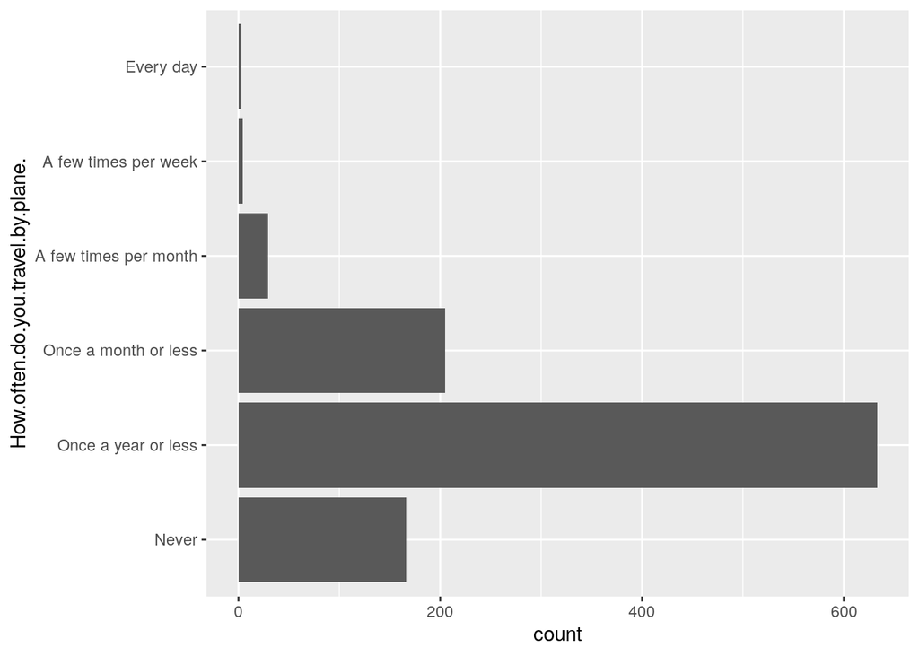

```r
fly$`How.often.do.you.travel.by.plane.` <- forcats::fct_relevel(fly$`How.often.do.you.travel.by.plane.`, "Never", "Once a year or less", "Once a month or less", "A few times per month", "A few times per week", "Every day")
ggplot(fly) + geom_bar(aes(x = `How.often.do.you.travel.by.plane.`)) + coord_flip()
```

**Example comment**: Most of the survey respondents fly once a year or less and the vast majority fly once a month or less.

+2.5 pts total:  
+0.5 pt for attempting question  
+0.5 pt for providing some sort of summary of the levels  
+0.5 pt for reordering correctly  
+0.5 pt for bar chart  
+0.5 pt for comment

4. In the demographic variables (`Education`, `Age`, and `Houshold.Income`), replace all occurrences of the empty string "" by a missing value `NA`. How many responses do not have any missing values? (Hint: the function `is.na` might come in handy)

```r
levels(fly$Education)[6] <- NA
levels(fly$Age)[5] <- NA
levels(fly$Household.Income)[6] <- NA

sum(!(is.na(fly$Education) | is.na(fly$Household.Income) | is.na(fly$Age)))
```

```
## [1] 824
```

```r
# will also accept a breakdown for each of the variables completed in any of the following ways
sum(is.na(fly$Education))
```

```
## [1] 39
```

```r
sum(!is.na(fly$Education))
```

```
## [1] 1001
```

```r
summary(is.na(fly$Education))
```

```
##    Mode   FALSE    TRUE
## logical    1001      39
```

+1.5 pts total:  
+0.5pt for attempting question  
+0.5pt for replacing the NAs  
+0.5pt for counting the NAs

5. Run the command below and interpret the output. What potential purpose can you see for the chart?

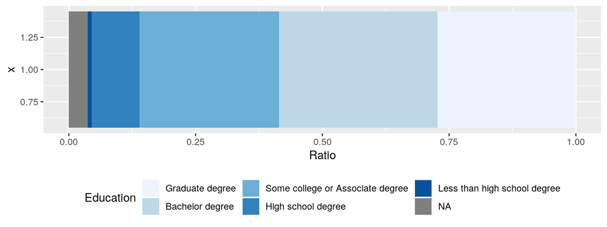

```r
library(ggplot2)
fly$Education = with(fly, factor(Education, levels = rev(levels(Education))))

ggplot(data = fly, aes(x = 1)) +
  geom_bar(aes(fill=Education), position="fill") +
  theme(legend.position="bottom") +
  scale_fill_brewer(na.value = "grey50") +
  labs(y = "Ratio") +
  coord_flip()
```

**Example interpretation**: This chart provides an easy way for us to see the proportion of respondents in each of the categories. Because there is a natural ordering of the levels, this chart would allow us to lump categories together mentally. For instance, we can easily see that approximately 40% of the respondents replied that their education level is less than a Bachelors degree.

+1 pt total:  
+0.5pt for attempting question  
+0.5pt for interpretation

6. Rename the variable `In.general..is.itrude.to.bring.a.baby.on.a.plane.` to `baby.on.plane.`. How many levels does the variable `baby.on.plane` have, and what are these levels? Rename the level labeled "" to “Not answered”. Reorder the levels of `baby.on.plane` from least rude to most rude. Put the level “Not answered” last. Draw a barchart of variable `baby.on.plane`. Interpret the result.

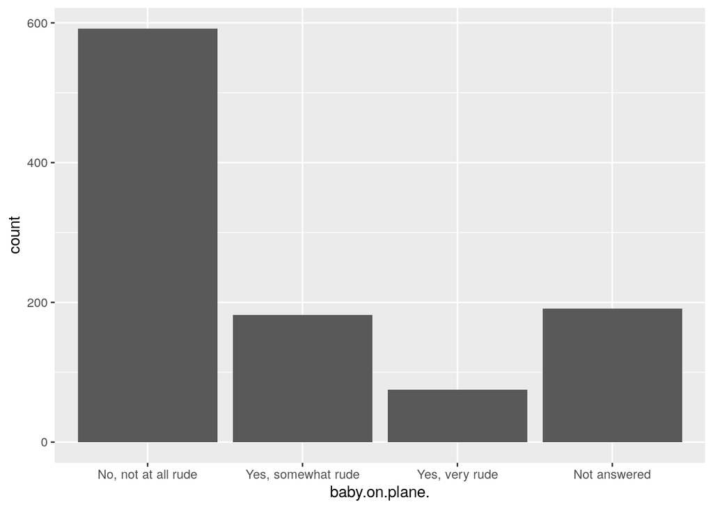

```r
names(fly)[19] <- "baby.on.plane."
levels(fly$`baby.on.plane.`)[1] <- "Not answered"
fly$`baby.on.plane.` <- forcats::fct_relevel(fly$`baby.on.plane.`, "No, not at all rude", "Yes, somewhat rude", "Yes, very rude", "Not answered")
ggplot(fly) + geom_bar(aes(x = `baby.on.plane.`))
```

**Example interpretation**: Only a small number of respondents consider it somewhat rude to bring a baby on a plane and an even smaller number consider it to be very rude.

+3 pts total:  
+0.5pt for attempting question  
+0.5pt for renaming the variable  
+0.5pt for renaming the level  
+0.5pt for reordering the levels  
+0.5pt for bar chart  
+0.5pt for interpretation

7. Investigate the relationship between gender and the variables `Do.you.have.any.children.under.18.` and `baby.on.plane`. How is the attitude towards babies on planes shaped by gender and having children under 18? Find a plot that summarises your findings (use `ggplot2`).

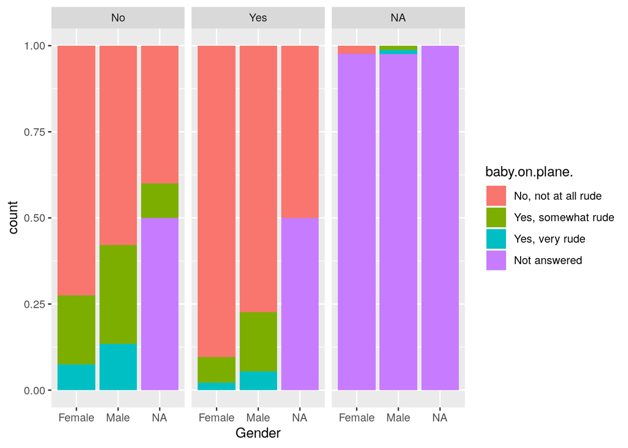

```r
levels(fly$`Do.you.have.any.children.under.18.`)[1] <- NA
levels(fly$Gender)[1] <- NA

ggplot(fly) + geom_bar(aes(x = Gender, fill = `baby.on.plane.`), position = "fill") + facet_grid(~`Do.you.have.any.children.under.18.`)
```

**Example interpretation**: It seems that those with children under 18 are less likely to be bothered by a baby on a plane. Additionally, whether or not the respondent had a child under 18 or not, if the respondent was a female, they were less likely to be bothered by a baby on a plane.

+1.5 pts total:  
+0.5pt for attempting question  
+0.5pt for 1 plot that includes all 3 variables  
+0.5pt for interpretation